# Fourth Corner and RQL Analysis

Heather Grab

April 24, 2018

#### Load libraries

```r
library(mvabund)## do not compile dependencies from source
library(lattice)
```

#### What types of questions/data is this method good for?

short answer: When you want to know what kinds of organisms occur where and why

long answer: A common strategy in any field looking at “why” is to look for predictor variables that can explain the response. In the case of studying why some taxa are abundant at a site while others are not, the relevant predictors are species traits.

The core idea of this approach is to fit a predictive model for species abundance as a function of environmental variables, species traits and their interaction. The environment trait interaction coefficients can be understood as the fourth corner and describes how environmental response across taxa varies as traits vary.

The essential components of a fourth corner analysis are the R, Q, and L matrices

R: the site by envoronment matrix that describes the envonmental conditions at each site

Q: the species by traits martix that describes the traits of each species (can be both quantitative and categorical)

L: the site by species matrix that describes which species occur at each site (can be quanitative or presence/absence)

#### Load the example dataset

##### About the example data

The example dataset is drawn from a study of pollinator communities across 3 different cropping systems in Northeastern USA. Our analysis will focus on just one of the three crops (watermelon) and its 45 pollinator species.

First our R matrix this is the site by environment matrix that includes data on the land cover (agricultrual and open natural habitats) at 300m and 1500m from the 17 sites. There are are few other variables included in the dataset that were not analyzed in the original manuscript so we will subset those out for the moment.

```r
envi <- read.csv("envi_watermelon.csv", row.names = 1); envi=envi[,c(1,2,5,6)] ## add row.names = 1 agrument to tell R that the first column should be treated as row names
head(envi)
```

```
##     ag_300 open_300 ag_1500 open_1500
## anc   34.9      6.0    17.1       9.0
## bra   49.6     20.2    25.9       9.9
## bri   37.3      2.9    13.3       9.4
## ced   52.1     15.1    19.1      10.6
## che   32.2      0.0    22.9       2.6
## lee   55.1      0.0    13.6       1.6
```

The Q matrix this is the species by trait matrix which includes a mix of categorical and quantitiative traits for each species. Missing data for any species will cause the model to fail

```r
traits <- read.csv("traits_watermelon.csv",row.names = 1)
head(traits)
```

```
##                          Nest_place  Sociality Parasitic   ITfam   PDrar20
## Agapostemon_sericeus           soil fac_social        No 1.90000  861.9756
## Agapostemon_texanus            soil fac_social        No 1.87400  819.8443
## Agapostemon_virescens          soil fac_social        No 2.16000  904.1070
## Augochlora_pura                wood   Solitary        No 1.59500 1663.8048
## Augochlorella_aurata           soil   Eusocial        No 1.53375 1778.9098
## Augochloropsis_metallica       soil   Solitary        No 1.90500 1151.2002
##                            tongue
## Agapostemon_sericeus     3.096000
## Agapostemon_texanus      3.492000
## Agapostemon_virescens    3.738375
## Augochlora_pura          2.754095
## Augochlorella_aurata     2.426700
## Augochloropsis_metallica 2.320000
```

The L matrix this is the site by species matrix. The default fourth corner model assumed a negative binomial error distribution so all values should be integer.

```r
abd <- read.csv("abd_watermelon.csv", row.names = 1)
abd[1:5, 1:5] # just viewing the first 5 rows and 5 columns
```

```
##     Agapostemon_sericeus Agapostemon_texanus Agapostemon_virescens
## anc                    0                   0                     1
## bra                    0                   0                     0
## bri                    0                   2                     0
## ced                    0                   0                     0
## che                    0                   0                     0
##     Augochlora_pura Augochlorella_aurata
## anc              24                    2
## bra              16                    2
## bri               0                    1
## ced               3                    0
## che               8                    2
```

#### Exploring the data

We can look the the relative abundance distributions for the community using the built in plotting functions

We first need to convert our L matrix (site x species) to a mvabund matrix object

```
## Kicking off BoxPlot sequence
```

```
## Overlapping points were shifted along the y-axis to make them visible.
```

```
##
##
## ABOUT TO PLOT THE FUNCTION
```

```
## Only the variables Bombus_impatiens, Lasioglossum_imitatum, Augochlora_pura, Ceratina_calcarata_dupla_miqmaki, Lasioglossum_versatum, Lasioglossum_pilosum, Lasioglossum_mitchelli, Melissodes_bimaculata, Peponapis_pruinosa, Triepeolus_remigatus, Augochlorella_aurata, Ceratina_strenua were included…
## (the variables with highest total abundance).
```

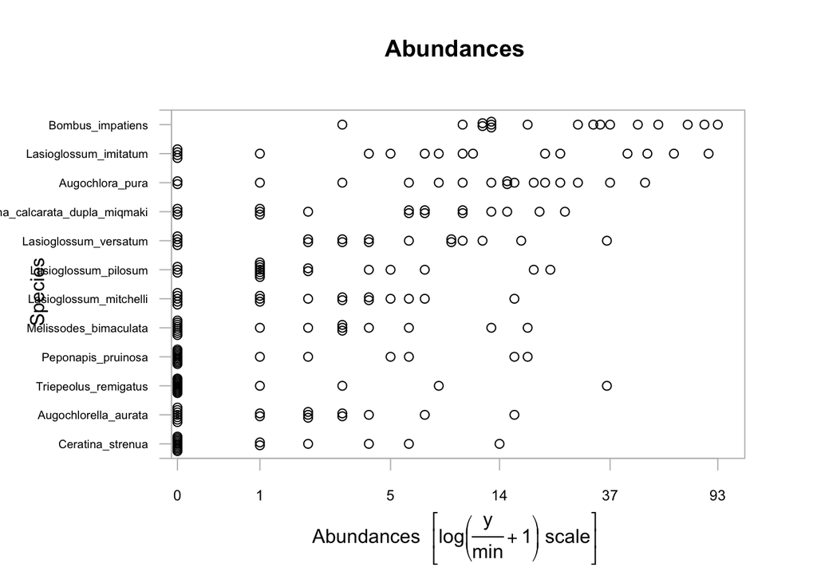

```r
bee_spp=mvabund(abd)
plot(bee_spp)
```

We can partition abundances based on categorical environmental variables

Our example dataset does not have any catergorical environmental variables so we will add one

```
## Overlapping points were shifted along the y-axis to make them visible.
```

```
##
##  PIPING TO 2nd MVFACTOR
```

```
## Only the variables Bombus_impatiens, Lasioglossum_imitatum, Augochlora_pura, Ceratina_calcarata_dupla_miqmaki, Lasioglossum_versatum, Lasioglossum_pilosum, Lasioglossum_mitchelli, Melissodes_bimaculata, Peponapis_pruinosa, Triepeolus_remigatus, Augochlorella_aurata, Ceratina_strenua were included…
## (the variables with highest total abundance).
```

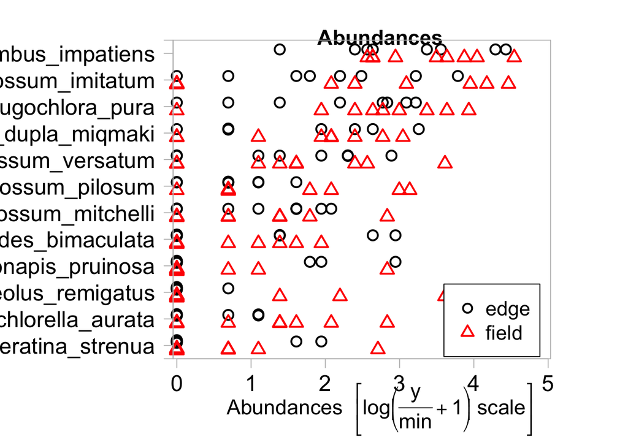

```r
envi2=envi
envi2$habitat="field"
envi2$habitat[1:8]<-"edge"
envi2$habitat=as.factor(envi2$habitat)

plot(bee_spp~envi2$habitat, tranformation = "no" )
```

By default the plot will only include the species with the highest total abundances. For each species plotted we can get a sense of whether they are more or less abundant in particular habitat types.

#### Multivariate GLM

Do communities differ across land use gradients?

```r
mod1 <- manyglm(bee_spp ~ envi$ag_300, family="poisson")
```

#### Check model assumptions

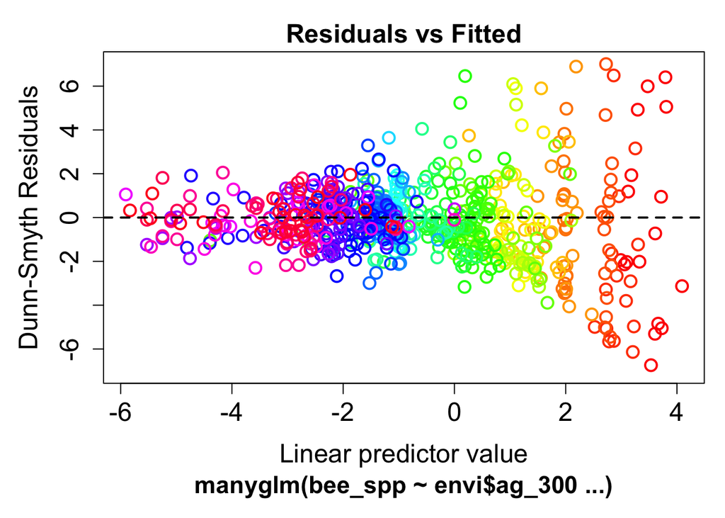

```r
plot(mod1)
```

Clearly we see a fan pattern in the model residuals, indicating a pattern of increasing variance at high abundances

Let’s try a negative binomial model

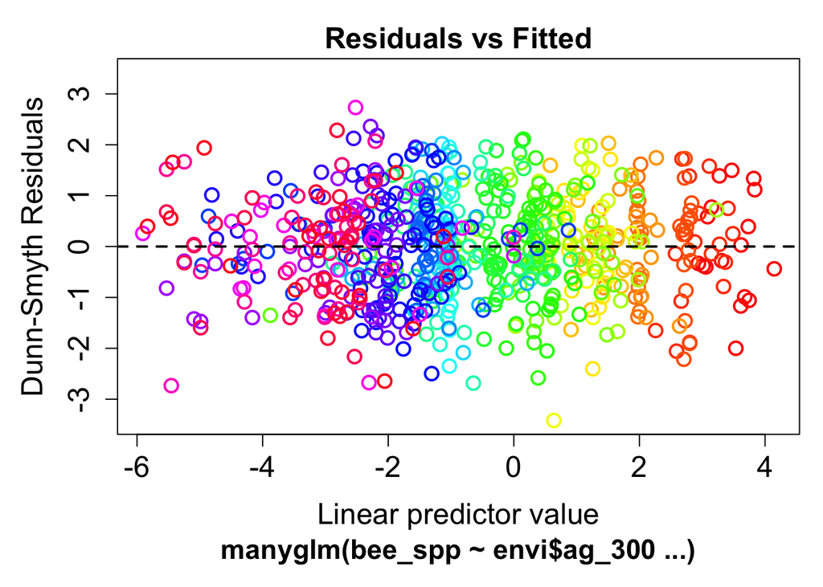

```r
mod2 <- manyglm(bee_spp ~ envi$ag_300, family="negative_binomial")
plot(mod2)
```

much better

#### Hypothesis testing with anova()

We can test the multivariate hypothesis of whether species composition varied across the habitats by using the anova function. This gives an analysis of deviance table where we use likelihood ratio tests and resampled p values to look for a significant effect of Habitat on the community data.

This is a bootstrap based test that can take a while to calculate on large datasets so for now we will set the number of reps to 99

```r
anova(mod2, nBoot=99)
```

```
## Time elapsed: 0 hr 0 min 1 sec
```

```
## Analysis of Deviance Table
##
## Model: manyglm(formula = bee_spp ~ envi$ag_300, family = "negative_binomial")
##
## Multivariate test:
##             Res.Df Df.diff   Dev Pr(>Dev)
## (Intercept)     16
## envi$ag_300     15       1 56.08     0.23
## Arguments:
##  Test statistics calculated assuming uncorrelated response (for faster computation)
##  P-value calculated using 99 resampling iterations via PIT-trap resampling (to account for correlation in testing).
```

We can see from the output that the cover of agriculture at the 300m radius does not drive differences in community composition.

Using the p.uni=“adjusted” agrument we determine whether any individual species is influenced by agricultural cover

```r
anova(mod2, p.uni="adjusted", nBoot=99)
```

```
## Time elapsed: 0 hr 0 min 1 sec
```

```
## Analysis of Deviance Table
##
## Model: manyglm(formula = bee_spp ~ envi$ag_300, family = "negative_binomial")
##
## Multivariate test:
##             Res.Df Df.diff   Dev Pr(>Dev)
## (Intercept)     16
## envi$ag_300     15       1 56.08     0.26
##
## Univariate Tests:
##             Agapostemon_sericeus          Agapostemon_texanus
##                              Dev Pr(>Dev)                 Dev Pr(>Dev)
## (Intercept)
## envi$ag_300                0.664     1.00               0.546     1.00
##             Agapostemon_virescens          Augochlora_pura
##                               Dev Pr(>Dev)             Dev Pr(>Dev)
## (Intercept)
## envi$ag_300                 0.029     1.00           0.044     1.00
##             Augochlorella_aurata          Augochloropsis_metallica
##                              Dev Pr(>Dev)                      Dev
## (Intercept)
## envi$ag_300                3.808     0.80                    1.253
##                      Bombus_bimaculatus          Bombus_griseocollis
##             Pr(>Dev)                Dev Pr(>Dev)                 Dev
## (Intercept)
## envi$ag_300     0.99              5.666     0.53               2.572
##                      Bombus_impatiens          Calliopsis_andreniformis
##             Pr(>Dev)              Dev Pr(>Dev)                      Dev
## (Intercept)
## envi$ag_300     0.94            3.037     0.90                    0.083
##                      Ceratina_calcarata_dupla_miqmaki
##             Pr(>Dev)                              Dev Pr(>Dev)
## (Intercept)
## envi$ag_300     1.00                            0.007     1.00
##             Ceratina_strenua          Halictus_confusus
##                          Dev Pr(>Dev)               Dev Pr(>Dev)
## (Intercept)
## envi$ag_300            8.512     0.21             0.158     1.00
##             Halictus_ligatus          Halictus_parallelus
##                          Dev Pr(>Dev)                 Dev Pr(>Dev)
```

[output cut: 58 more lines]

```
##                      Megachile_mendica          Melissodes_bimaculata
##             Pr(>Dev)               Dev Pr(>Dev)                   Dev
## (Intercept)
## envi$ag_300     1.00             0.014     1.00                 0.532
##                      Peponapis_pruinosa          Triepeolus_remigatus
##             Pr(>Dev)                Dev Pr(>Dev)                  Dev
## (Intercept)
## envi$ag_300     1.00              0.265     1.00                    1
##                      Xylocopa_virginica
##             Pr(>Dev)                Dev Pr(>Dev)
## (Intercept)
## envi$ag_300     0.99              0.535     1.00
## Arguments:
##  Test statistics calculated assuming uncorrelated response (for faster computation)
## P-value calculated using 99 resampling iterations via PIT-trap resampling (to account for correlation in testing.
```

#### Multivariate SDM

The simplest form is a multivariate species distribution model (SDM) which predicts the abundance of each species based only on the environmental variables. The form of this model is essentially a negative binomial GLM with species as a fixed effect and a species by envi interaction.

if your data are a binomial, average abundace per site, coverage per m^2 or some other non-integer value, the form of the model can be adjusted using the family and method parameters.

```r
sdm_fit=traitglm(abd,envi)
```

```
## No traits matrix entered, so will fit SDMs with different env response for each spp
```

View the standardized model coefficients for each species. Because all predictors are standardised, you can interpret the size of coefficients as a measure of importance. As interaction terms, the fourth coefficients each have an interpretation as the amount by which a unit (1 sd) change in the trait variable changes the slope of the relationship between abundance and a given environmental variable.

```r
sdm_fit$fourth
```

```
##                                               ag_300     open_300
## names.L.Agapostemon_texanus               0.07077555 -0.251224790
## names.L.Agapostemon_virescens            -0.27369613 -0.278524992
## names.L.Augochlora_pura                   0.07087176 -0.081921637
## names.L.Augochlorella_aurata              0.01058551  0.027962393
## names.L.Augochloropsis_metallica          5.29505822  4.667881410
## names.L.Bombus_bimaculatus                1.24094122 -0.692567248
## names.L.Bombus_griseocollis              -0.69330815  0.039461273
## names.L.Bombus_impatiens                  0.16627112  0.014862421
## names.L.Calliopsis_andreniformis         -1.74916223 -1.276284900
## names.L.Ceratina_calcarata_dupla_miqmaki  0.11617828 -0.020516676
## names.L.Ceratina_strenua                 -0.43813946 -0.233178109
## names.L.Halictus_confusus                 0.09770080  0.021901354
## names.L.Halictus_ligatus                  0.15058983 -0.186928540
## names.L.Halictus_parallelus               1.97113481  1.080836679
## names.L.Halictus_rubicundus               0.20829094  0.141482803
## names.L.Lasioglossum_admirandum          -1.24659501  0.619070701
## names.L.Lasioglossum_albipenne            5.29505823  4.667881410
## names.L.Lasioglossum_bruneri              1.26451099  1.105401832
## names.L.Lasioglossum_coriaceum            0.27949487 -0.465071678
## names.L.Lasioglossum_cressonii           -0.17829593  0.380266893
## names.L.Lasioglossum_ephialtum            0.11720607  0.137180620
## names.L.Lasioglossum_illinoense           0.00584229  0.032471153
## names.L.Lasioglossum_imitatum            -0.05772238  0.037096520
## names.L.Lasioglossum_leucocomum           0.07601941  0.008056101
## names.L.Lasioglossum_mitchelli            0.09171221  0.143195776
## names.L.Lasioglossum_nymphaearum          0.07147500 -0.016278320
## names.L.Lasioglossum_oblongum             5.29505823  4.667881410
## names.L.Lasioglossum_obscurum            -0.13873183  1.133991247
## names.L.Lasioglossum_paradmirandum       -0.01115180  0.351235875
## names.L.Lasioglossum_pectorale            0.05631242 -0.150347237
## names.L.Lasioglossum_pilosum              0.08423771 -0.009815978
## names.L.Lasioglossum_rozeni              -0.27197793  3.110746693
## names.L.Lasioglossum_smilacinae          -0.08199312 -0.744703266
## names.L.Lasioglossum_tegulare             0.06481935 -0.091467795
## names.L.Lasioglossum_trigeminum           0.07169981 -0.094898714
## names.L.Lasioglossum_truncatum            0.14610680  0.169557695
## names.L.Lasioglossum_versatum             0.14805605  0.062816858
## names.L.Lasioglossum_weemsi               0.09968842 -0.005540382
## names.L.Lasioglossum_zephyrum             0.10597951  0.091692984
```

[output cut: 35 more lines]

```
## names.L.Lasioglossum_pectorale            0.06390930  0.31246356
## names.L.Lasioglossum_pilosum              0.28641854  0.18050911
## names.L.Lasioglossum_rozeni              -3.94662040  2.45836893
## names.L.Lasioglossum_smilacinae          -0.95093246  0.43263196
## names.L.Lasioglossum_tegulare             0.44901123  0.26570377
## names.L.Lasioglossum_trigeminum           0.29640242  0.01350734
## names.L.Lasioglossum_truncatum            0.32033187  0.07463766
## names.L.Lasioglossum_versatum             0.32325817  0.12552940
## names.L.Lasioglossum_weemsi               0.30253932  0.16101879
## names.L.Lasioglossum_zephyrum             0.45406798  0.18526505
## names.L.Megachile_mendica                -0.09864339 -0.16043910
## names.L.Melissodes_bimaculata             0.36423635  0.02488645
## names.L.Peponapis_pruinosa                0.18584180  0.33618745
## names.L.Triepeolus_remigatus              0.21405349  0.59659613
## names.L.Xylocopa_virginica               -0.03515747 -0.24084414
```

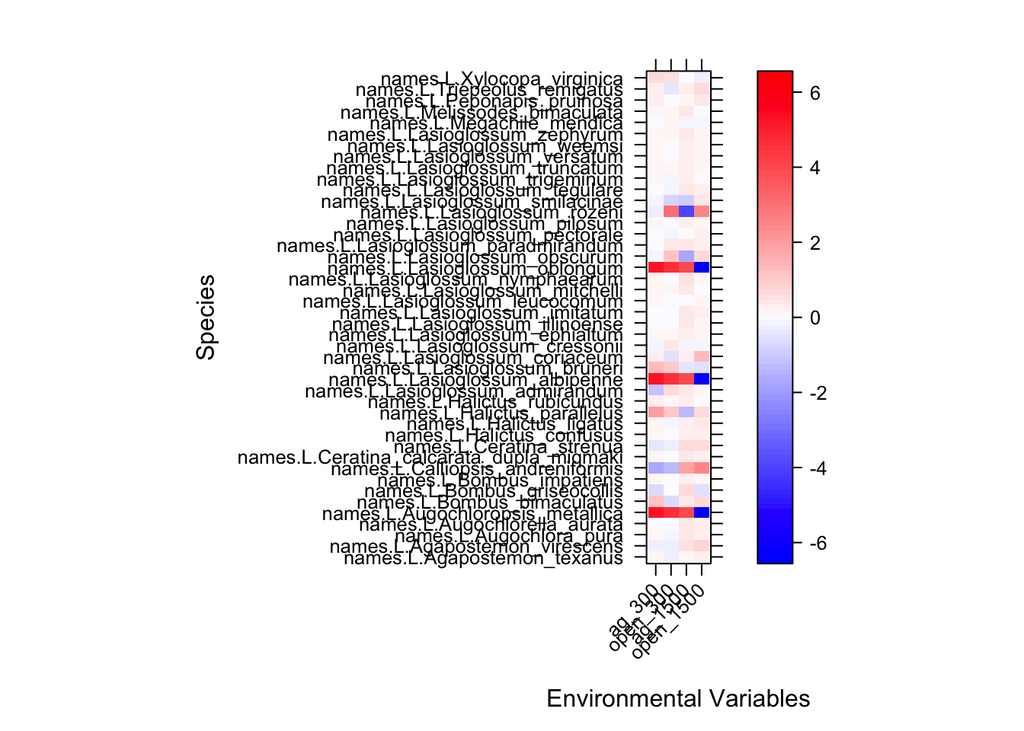

```r
a        = max( abs(sdm_fit$fourth.corner) )
colort   = colorRampPalette(c("blue","white","red"))
plot.spp = levelplot(t(as.matrix(sdm_fit$fourth.corner)), xlab="Environmental Variables",
 ylab="Species", col.regions=colort(100), at=seq(-a, a, length=100),
 scales = list( x= list(rot = 45)))
print(plot.spp)
```

While this is intersting for exploring the data we might guess that certain species are responding in a particular way based on their traits.

We can expand the analysis by adding the trait matrix and explicitly looking for the trait by environment interactions (fourth corner)

```r
fit=traitglm(abd,envi,traits)
fit$fourth #print fourth corner terms
```

```
##                           ag_300   open_300     ag_1500   open_1500
## Nest_placehole      -0.022126259  0.2998671 -0.38177965 -0.27554344
## Nest_placesoil       0.421851422  0.6611413 -0.21841342  0.03728946
## Nest_placestem       0.168049151  0.4240527 -0.05627609 -0.01797214
## Nest_placewood       0.216954212  0.2715265 -0.08037851  0.23241242
## Socialityfac_social  0.001050133 -0.1646033 -0.08384819  0.13099355
## SocialitySolitary   -0.028235695 -0.2131141 -0.01025747 -0.00830944
## ParasiticYes         0.179256142 -0.1374079 -0.13056093  0.24762981
## ITfam                0.812977896  0.9871009 -0.95328340 -0.95172845
## PDrar20              0.096645095  0.3719838  0.09255824 -0.32827087
## tongue              -0.213393730 -0.3944371  0.59674640  0.71914573
```

We can evaluate whether the data meet model assumptions using the plot function

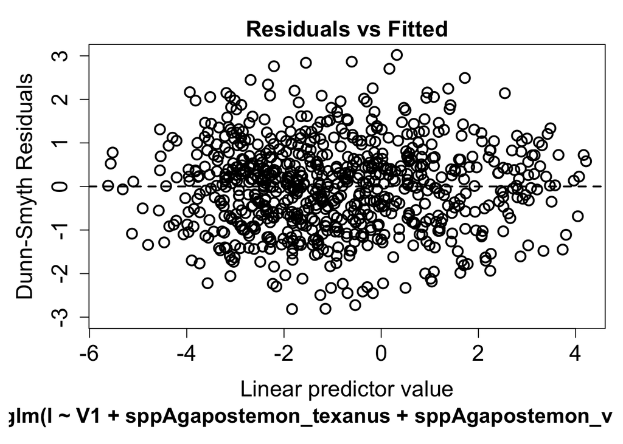

```r
plot(fit)
```

```r
anova(fit, nBoot = 10)
```

```
## Using block resampling...
## Resampling begins for test 1.
##  Resampling run 0 finished. Time elapsed: 0.01 minutes...
## Time elapsed: 0 hr 0 min 14 sec
```

```
## Analysis of Deviance Table
##
## Model  1: traitglm(L = abd, R = envi, Q = traits, get.fourth = FALSE)
## Model  2: traitglm(L = abd, R = envi, Q = traits)
##
## Multivariate test:
##                           Res.Df Df.diff   Dev Pr(>Dev)
## Main effects only            712
## env:trait (fourth corner)    672      40 69.89    0.182
## Arguments: P-value calculated using 10 resampling iterations via PIT-trap block resampling (to account for correlation in testing).
```

we can see from the output that the model we are fitting is pretty complex

we also see that the overall trait by environment interaction term is not supported (P>0.05)

We can also explore the effects of individual trait by environment interactions using the summary function

** Warning this is slow **

we will limilt the number of bootstrap reps to 10 (nBoot=10) but 1000 should be using for final analyses

```r
summary(fit, nBoot=10)
```

```
##
## Test statistics:
##                                     wald value Pr(>wald)
## (Intercept)                              7.628    0.0909 .
## sppAgapostemon_texanus                   0.139    0.7273
## sppAgapostemon_virescens                 0.201    0.7273
## sppAugochlora_pura                       6.353    0.0909 .
## sppAugochlorella_aurata                  3.604    0.0909 .
## sppAugochloropsis_metallica              0.763    0.1818
## sppBombus_bimaculatus                    0.721    0.3636
## sppBombus_griseocollis                   0.737    0.2727
## sppBombus_impatiens                      7.293    0.0909 .
## sppCalliopsis_andreniformis              0.024    1.0000
## sppCeratina_calcarata_dupla_miqmaki      5.233    0.0909 .
## sppCeratina_strenua                      2.142    0.0909 .
## sppHalictus_confusus                     3.044    0.0909 .
## sppHalictus_ligatus                      2.611    0.0909 .
## sppHalictus_parallelus                   1.084    0.1818
## sppHalictus_rubicundus                   1.081    0.3636
## sppLasioglossum_admirandum               0.768    0.3636
## sppLasioglossum_albipenne                0.729    0.2727
## sppLasioglossum_bruneri                  0.586    0.4545
## sppLasioglossum_coriaceum                0.828    0.3636
## sppLasioglossum_cressonii                0.290    0.7273
## sppLasioglossum_ephialtum                0.568    0.5455
## sppLasioglossum_illinoense               1.700    0.0909 .
## sppLasioglossum_imitatum                 6.435    0.0909 .
## sppLasioglossum_leucocomum               1.319    0.0909 .
## sppLasioglossum_mitchelli                3.927    0.0909 .
## sppLasioglossum_nymphaearum              1.303    0.1818
## sppLasioglossum_oblongum                 0.771    0.4545
## sppLasioglossum_obscurum                 0.291    0.6364
## sppLasioglossum_paradmirandum            2.800    0.0909 .
## sppLasioglossum_pectorale                1.488    0.2727
## sppLasioglossum_pilosum                  4.471    0.0909 .
## sppLasioglossum_rozeni                   0.966    0.1818
## sppLasioglossum_smilacinae               0.758    0.3636
## sppLasioglossum_tegulare                 2.080    0.0909 .
## sppLasioglossum_trigeminum               0.243    0.9091
## sppLasioglossum_truncatum                0.340    0.8182
```

[output cut: 46 more lines]

```
## open_1500.Nest_placehole                 0.657    0.1818
## open_1500.Nest_placesoil                 0.094    1.0000
## open_1500.Nest_placestem                 0.083    1.0000
## open_1500.Nest_placewood                 0.689    0.4545
## open_1500.Socialityfac_social            0.944    0.1818
## open_1500.SocialitySolitary              0.044    0.9091
## open_1500.ParasiticYes                   1.808    0.0909 .
## open_1500.ITfam                          1.671    0.2727
## open_1500.PDrar20                        2.441    0.0909 .
## open_1500.tongue                         1.202    0.4545
## ---
## Signif. codes:  0 '***' 0.001 '**' 0.01 '*' 0.05 '.' 0.1 ' ' 1
##
## Test statistic:  24.52, p-value: 0.0909
## Arguments: P-value calculated using 10 resampling iterations via pit.trap resampling.
```

We can plot the results in a heatmap similar to the SDM plot above

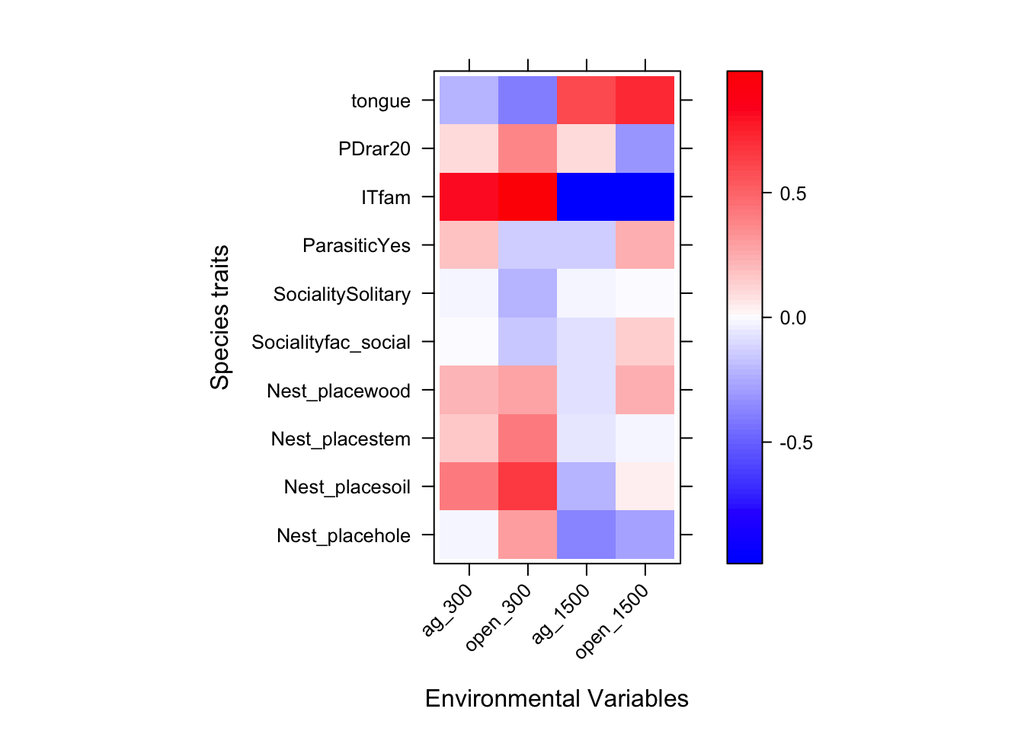

```r
a        = max( abs(fit$fourth.corner) )
colort   = colorRampPalette(c("blue","white","red"))
plot.4th = levelplot(t(as.matrix(fit$fourth.corner)), xlab="Environmental Variables",
 ylab="Species traits", col.regions=colort(100), at=seq(-a, a, length=100),
 scales = list( x= list(rot = 45)))
print(plot.4th)
```

#### adding a LASSO penalty

Given that there are many traits and even environmental factors that are not strong predictors of abundance, we can reduce the number of predictor terms in our models using various automatic model selection algorithims

LASSO is an optimization algorithm (Least Absolute Shrinkage and Selection Operator) that performs both variable selection and regularization in order to enhance the prediction accuracy and interpretability of the statistical model it produces.

LASSO is a great machine learning tool for dealing with complex datasets and had broad applications to many statistical methods. Luck for us, LASSO comes baked in to the mvabund package. All we need to do is add the method=“glm1path” argument

```r
ft1=traitglm(abd,envi,traits,method="glm1path")
ft1$fourth #notice LASSO penalty has shrunk many interactions to zero
```

```
##                          ag_300    open_300      ag_1500   open_1500
## Nest_placecavity     0.00000000  0.00000000  0.000000000 -0.03615099
## Nest_placehole       0.00000000  0.00000000  0.000000000 -0.07109140
## Nest_placesoil       0.00000000  0.03832670 -0.005213896  0.00000000
## Nest_placestem      -0.04997808  0.00000000  0.017326634  0.05622886
## Nest_placewood       0.00000000  0.00000000  0.000000000  0.00000000
## SocialityEusocial    0.00000000  0.00808636  0.000000000 -0.01038243
## Socialityfac_social  0.00000000  0.00000000  0.000000000  0.00000000
## SocialitySolitary    0.00000000 -0.01319900  0.000000000  0.00000000
## ParasiticYes         0.10892203 -0.03955369  0.000000000  0.13468582
## ITfam                0.19200395  0.00000000 -0.063254087  0.00000000
## PDrar20              0.00000000  0.06146317  0.061183593 -0.09979393
## tongue               0.00000000  0.00000000  0.000000000  0.00000000
```

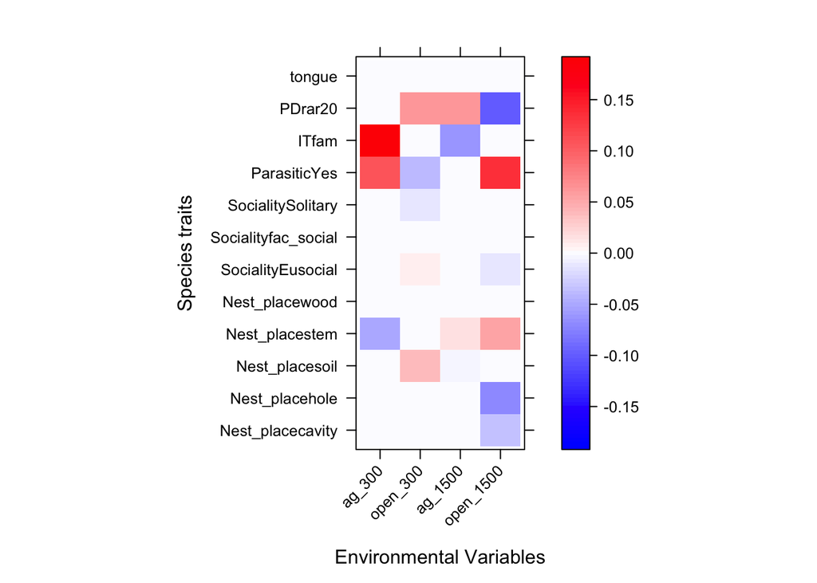

```r
library(lattice)
a        = max( abs(ft1$fourth.corner) )
colort   = colorRampPalette(c("blue","white","red"))
plot.4th = levelplot(t(as.matrix(ft1$fourth.corner)), xlab="Environmental Variables",
 ylab="Species traits", col.regions=colort(100), at=seq(-a, a, length=100),
 scales = list( x= list(rot = 45)))
print(plot.4th)
```